# Task 1

Mikhail Zhilkin

2017-09-30

```r
library(scales)
library(tidyverse)
```

Import the data set:

```r
df <- readxl::read_excel(
    "Task11part-2hr30mins.xlsx",
    range = cell_cols("A:D")
)
```

```r
head(df)
```

| PlayerID | Activity | Country | Group |
| --- | --- | --- | --- |
| 1 | 417.928046 | Ofu | 1 |
| 2 | 1.897277 | Ofu | 4 |
| 3 | 1868.364401 | Ofu | 3 |
| 4 | 6319.280527 | Ofu | 5 |
| 5 | 1044.820116 | Ofu | 5 |
| 6 | 299.231094 | Ofu | 5 |

Distribution of players across groups looks fine:

```r
df %>%
    count(Country, Group) %>%
    spread(Country, n)
```

|  | Group | Aunuu | Ofu | Olosega | Rose Atoll | Swains Island | Tau |
| --- | --- | --- | --- | --- | --- | --- | --- |
| 1 | 1 | 4076 | 5575 | 3202 | 3074 | 2608 | 3535 |
| 2 | 2 | 4006 | 5377 | 3239 | 2909 | 2546 | 3535 |
| 3 | 3 | 4050 | 5346 | 3091 | 2939 | 2644 | 3495 |
| 4 | 4 | 4065 | 5428 | 3167 | 2911 | 2551 | 3509 |
| 5 | 5 | 3916 | 5553 | 3136 | 2907 | 2569 | 3558 |

Gross revenue per player would indicate that Group 3 ($25 bonus) performed best:

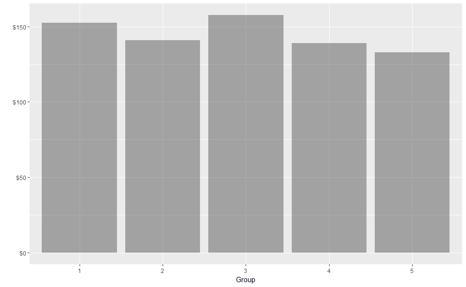

```r
df %>%
    mutate(GrossRev = Activity * .0213) %>%
    group_by(Group) %>%
    summarise(mean(GrossRev)) %>%
    ggplot() +
        geom_col(aes(ordered(Group), `mean(GrossRev)`), alpha = .5) +
        labs(x = "Group", y = "") +
        scale_y_continuous(labels = dollar_format())
```

Net revenue (gross revenue minus bonus) gives victory by a slim margin to Group 4 ($5 bonus):

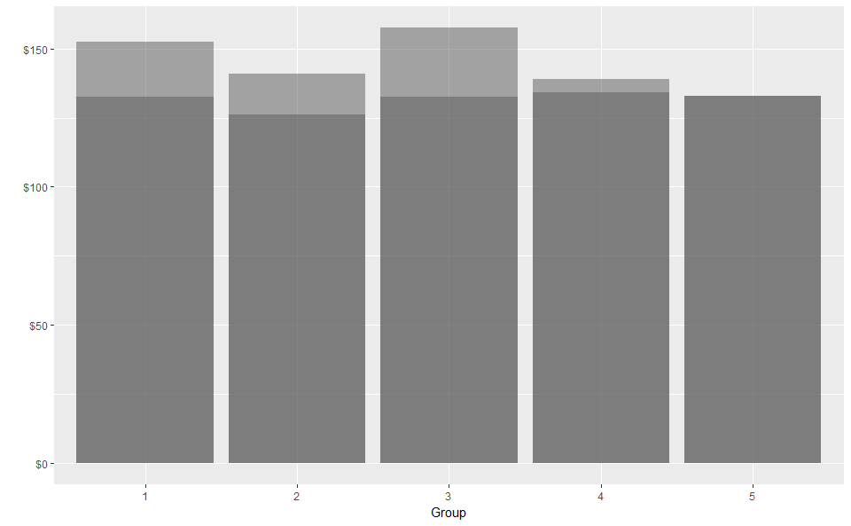

```r
df %>%
    mutate(
        GrossRev = Activity * .0213,
        NetRev = GrossRev - c(20, 15, 25, 5, 0)[Group]
    ) %>%
    group_by(Group) %>%
    summarise(mean(GrossRev), mean(NetRev)) %>%
    ggplot() +
        geom_col(aes(ordered(Group), `mean(GrossRev)`), alpha = .5) +
        geom_col(aes(ordered(Group), `mean(NetRev)`), alpha = .5) +
        labs(x = "Group", y = "") +
        scale_y_continuous(labels = dollar_format())
```

Different results in different countries suggest that things are more complicated, with no group winning across the board:

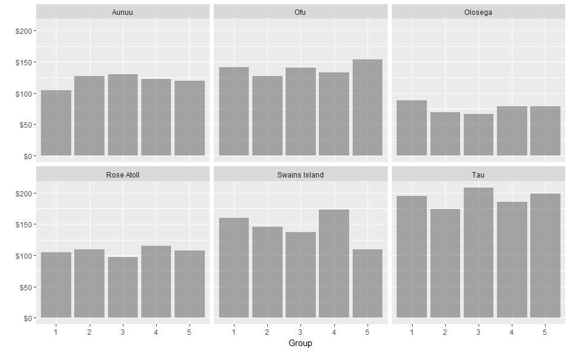

```r
df %>%
    mutate(NetRev = Activity * .0213 - c(20, 15, 25, 5, 0)[Group]) %>%
    group_by(Country, Group) %>%
    summarise(mean(NetRev)) %>%
    ggplot() +
        facet_wrap(~Country) +
        geom_col(aes(ordered(Group), `mean(NetRev)`), alpha = .5) +
        labs(x = "Group", y = "") +
        scale_y_continuous(labels = dollar_format())
```

Distribution of net revenue is extremely uneven, with 6.9% of top spenders responsible for 80% of it (the downward bend is due to players with *negative* net revenue):

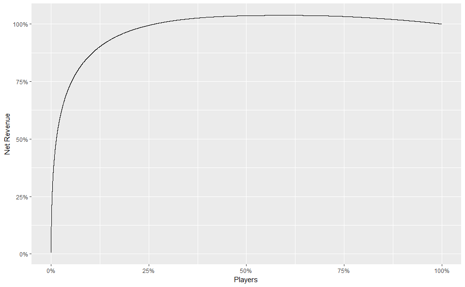

```r
df %>%
    mutate(NetRev = Activity * .0213 - c(20, 15, 25, 5, 0)[Group]) %>%
    arrange(-NetRev) %>%
    transmute(x = row_number() / n(), y = cumsum(NetRev) / sum(NetRev)) %>%
    ggplot() +
        geom_line(aes(x, y)) +
        labs(x = "Players", y = "Net Revenue") +
        scale_x_continuous(labels = percent_format()) +
        scale_y_continuous(labels = percent_format())
```

```r
tmp <- expand.grid(
    Country = unique(df$Country),
    Group = unique(df$Group),
    stringsAsFactors = FALSE
)
```

```r
df2 <- do.call(
    rbind,
    mapply(
        function(a, b) {
            x <- df %>% filter(Country == a, Group == b) %>% pull(Activity)

            y <- quantile(
                replicate(1e+4, { mean(sample(x, length(x), replace = TRUE)) }),
                c(.05, .95)
            )

            tibble(
                Country = a,
                Group = b,
                Lower = y[1] * .0213 - c(20, 15, 25, 5, 0)[b],
                Upper = y[2] * .0213 - c(20, 15, 25, 5, 0)[b]
            )
        },
        tmp$Country,
        tmp$Group,
        SIMPLIFY = FALSE
    )
)
```

Swains Island appears to be the only market with a clear indication that the campaign has been beneficial, with control group falling behind. Otherwise, one cannot draw conclusions from the data available:

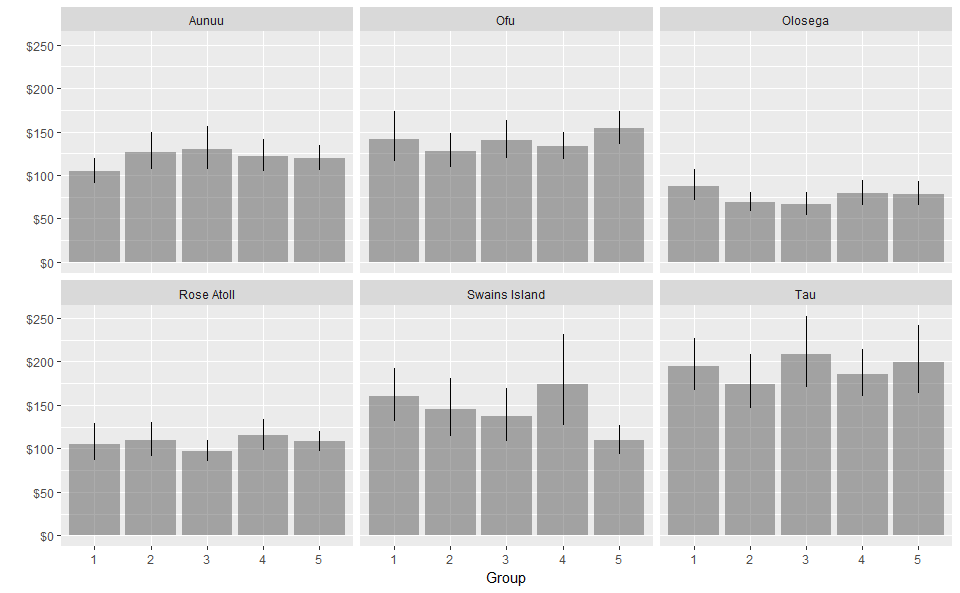

```r
df %>%
    mutate(NetRev = Activity * .0213 - c(20, 15, 25, 5, 0)[Group]) %>%
    group_by(Country, Group) %>%
    summarise(mean(NetRev)) %>%
    inner_join(df2) %>%
    ggplot() +
        facet_wrap(~Country) +
        geom_col(aes(ordered(Group), `mean(NetRev)`), alpha = .5) +
        geom_segment(aes(
            x = ordered(Group),
            xend = ordered(Group),
            y = Lower,
            yend = Upper
        )) +
        labs(x = "Group", y = "") +
        scale_y_continuous(labels = dollar_format())
```

Suggestions for future analysis & research:

- Identify biggest spenders and remove them from this kind of analysis, which may result in more narrow confidence intervals. (This is based on a risky assumption that high spenders’ behaviour isn’t affected by a small bonus.)
- Segment players based on their pre-test behaviour (e.g. low/medium/high spenders) and analyse the impact of bonus campaign on each segment separately.
- If possible, test campaign on a larger number of users.